# Analysis of Environmental Data Lab

Lab 12: Bonus Lab

# Lab Concepts and Objectives

This is an optional bonus lab in which you can earn back up to 5% of your total lab course grade, but be warned: the questions aren’t easy!

Since this is an extra-credit assignment, the help you get from me and your TA is limited. We can answer clarifying questions, however we can’t help with content.

Feel free to complete as much or as little of this assignment as you’d like. The points you earn will be added to your overall course grade, not to exceed 100%.

This lab covers three techniques that we’ve mentioned briefly in the lecture: Additive models, nonlinear least squares, and logistic regression. In order to complete this lab, you’ll need some of the material you’ve used to answer questions in previous labs, most notably labs 3, 5, and 11.

# Additive Models: LOWESS

Recall our power analysis of sample size for the Brown Creeper and Late-Successional Forest cover.

Here’s plot of a realization of the simulation with 30 replicates at each sample size:

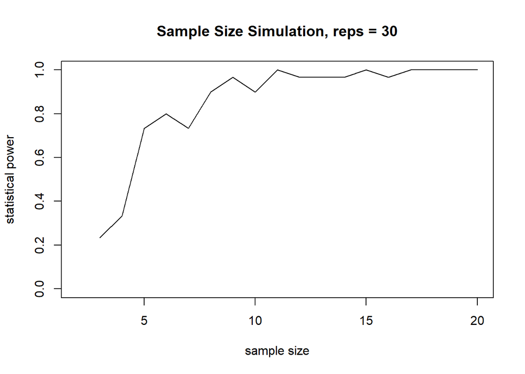

## Locally Weighted Sums of Squares

The plot looks pretty jagged; we can use a smoothing procedure to make the plot less rough. Take a look at an example before we dive into details:

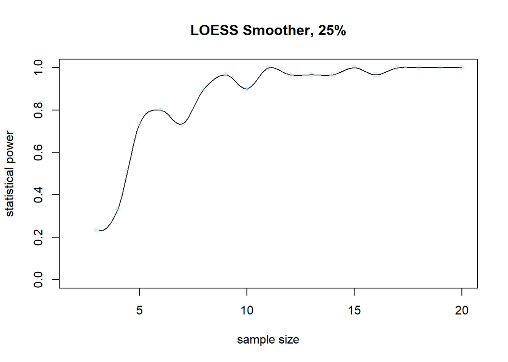

Locally Weighted Sums of Squares (LOWESS, or sometimes LOESS) is a commonly-used smoothing procedure.

LOWESS works by fitting ‘local weighted regressions’ at each value of the predictors.  
Predictors with nearby values are given more ‘weight’ in the model-fitting procedure.

The proportion of data points used in the locally weighted regressions affects the shape of the curve. Using a greater proportion of the data makes the curve *smoother* - it “smooths out” local detail. Using a smaller portion of the data for each local regression preserves local details.

Take a look at LOESS applied to the same data with different amounts of smoothing:

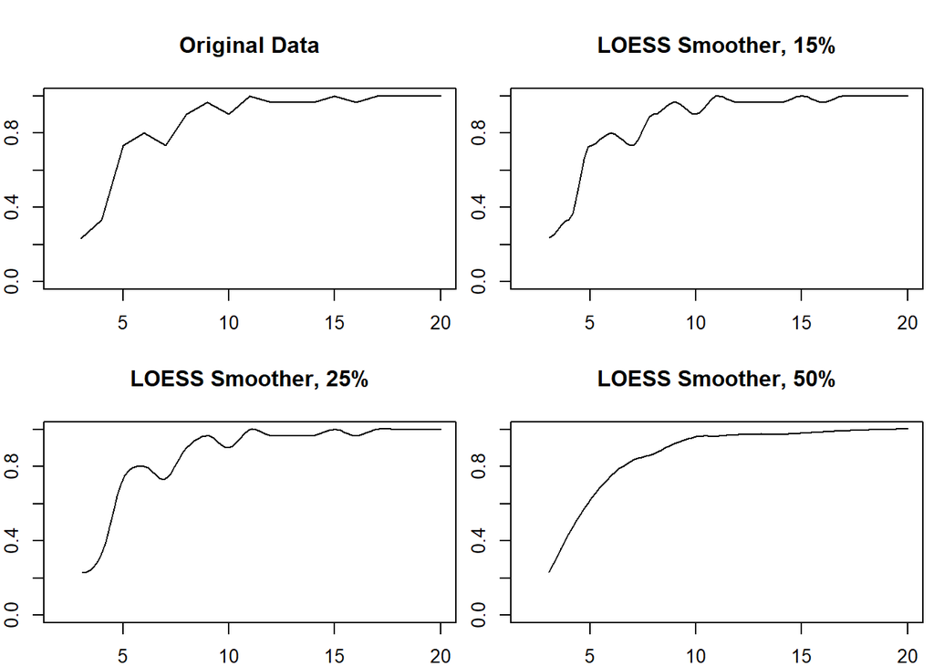

## Fitting a LOWESS Model

The syntax for fitting a LOWESS model is very similar to what we’ve seen with `lm()`.

Here I’ve fit a model using 50% of the data (the `span` argument).

```r
fit_lowess_50 = loess(power ~ sample_size, data = sim_sample_size, span = 0.5)
```

I can use `predict()` to create a `data.frame` of new values for plotting my smoother:

```r
newdata_sample_size = data.frame(sample_size = seq(2, 20, length.out = 100))
```

Finally, I can plot it:

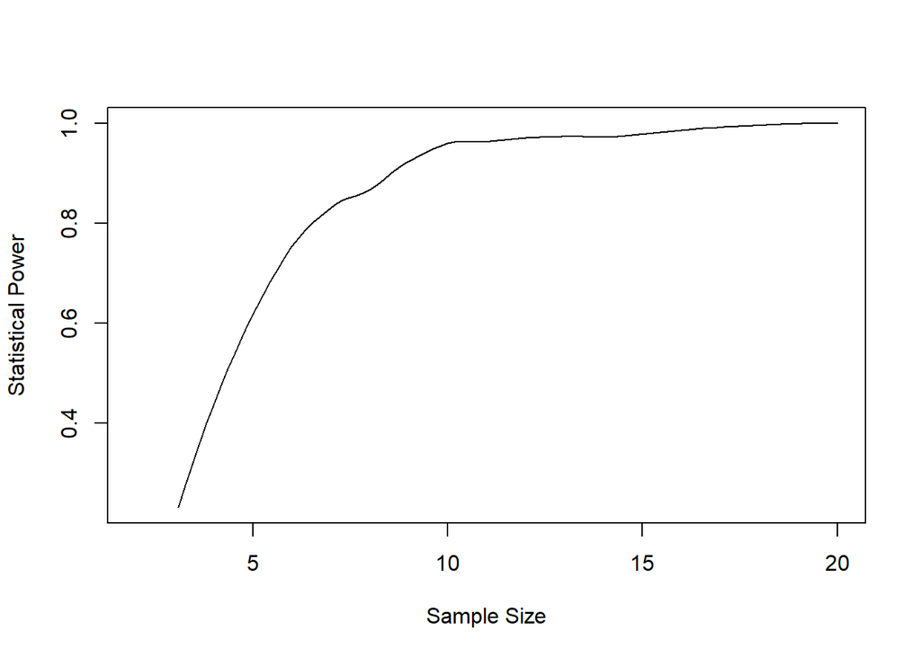

```r
plot(
  x = newdata_sample_size$sample_size,
  y = predict(fit_lowess_50, newdata = newdata_sample_size),
  type = "l",
  ylab = "Statistical Power", xlab = "Sample Size")
```

If I wanted to be fancy, I could plot the non-smoothed simulation results in a different color and include a legend:

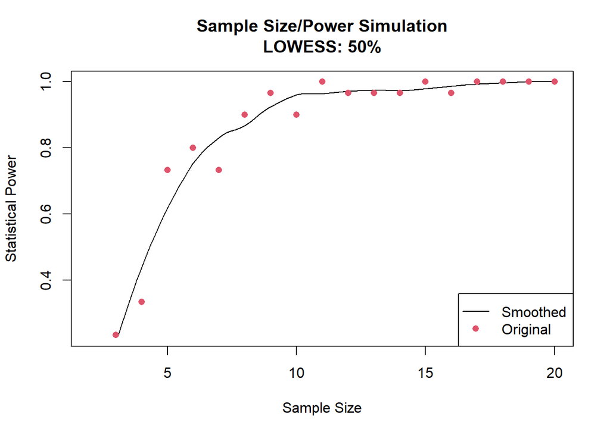

You now know enough R to make the fancy version of the plot yourself!

# Nonlinear Least Squares

Do you remember the Ricker function?

[figure not shown]

And the Ricker function models we fit by hand in lab 5?

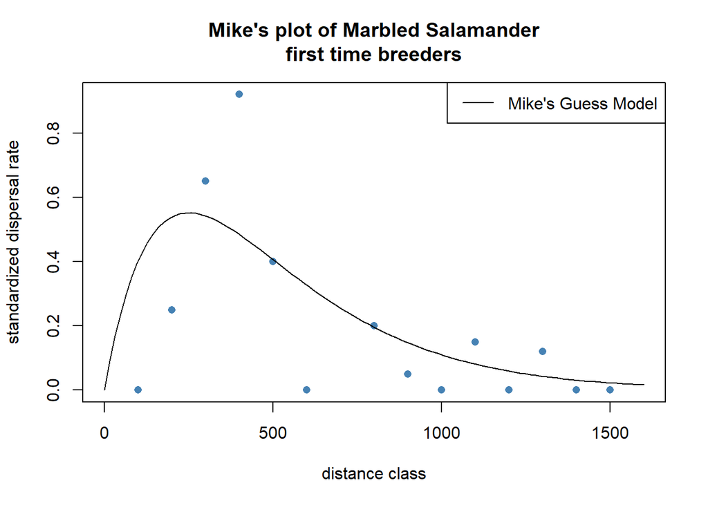

We can use *Nonlinear Least Squares* to fit an arbitrary function to data using a least squares criterion. I’ll present an example.

**Background on the example**

I performed the following prior to running the example code I show below. You should recreate these steps prior to following along. I’ll leave it up to you to review materials from lab 5 if you need a refresher on how to do these steps.

- Note that in the example code, I use a data.frame called `dat_dispersal`.
- I read the *dispersal.csv* file from lab 5 using `read.csv()` and `here()`.
- I’ve run the code to store `ricker_fun()` into my global environment, and I used my guesses for the two parameters along with `curve()` to plot my guess fit.

## Fitting a NLS model in R

We’ll be using the `nls()` function to fit our model.

Recall that nonlinear least squares attempts to find the parameter values of a function that minimize the sum of squared errors (i.e. the sum of squared residuals). Unlike linear regression, the function doesn’t have to be linear in the parameters.  
The Ricker function is *definitely* not linear in the parameters!

Here’s the syntax to fit a Ricker model:

```r
fit_ricker_nls = nls(
  disp.rate.ftb ~ ricker_fun(dist.class, a, b),
  data = dat_dispersal,
  start = list(b = 0, a = 1))
summary(fit_ricker_nls)
```

```
##
## Formula: disp.rate.ftb ~ ricker_fun(dist.class, a, b)
##
## Parameters:
##   Estimate Std. Error t value Pr(>|t|)
## b 0.003586   0.000913   3.928  0.00201 **
## a 0.004471   0.001889   2.367  0.03558 *
## ---
## Signif. codes:  0 '***' 0.001 '**' 0.01 '*' 0.05 '.' 0.1 ' ' 1
##
## Residual standard error: 0.2149 on 12 degrees of freedom
##
## Number of iterations to convergence: 17
## Achieved convergence tolerance: 9.07e-06
##   (1 observation deleted due to missingness)
```

The syntax shares some similarities to that of `lm()`, but notice that the model formula uses our ricker function. Notice also that there is a `start` argument. We use `start` to provide `nls()` starting parameter values from which to search for the optimal values.

In the interest of not re-inventing wheels, I’ll refer you to a good blog post on using `nls()` [here](https://www.datatechnotes.com/2020/11/curve-fitting-with-nonlinear-least-squares-in-r.html). It’s got a good explanation of the syntax, as well as a nice example.

NLS fitting uses iterative methods to find the optimal parameter values. The algorithm uses the current parameter values to make guesses for the next iteration. When subsequent iterations do not result in changed parameter values (within a tolerance), the algorithm terminates.

The output of the model summary tells us how many iterations were needed to find the optimal parameter values.

NLS can be very sensitive to your initial guesses for parameter values.

Unintuitively, if your initial guesses are very close to the the true optima, the algorithm can fail and return an error. Note that the initial values I provided (0 and 1) are very different from the true optima.

## Plotting an NLS model

Start by plotting your data points. I’ll let you create your own scatterplot, it should look something like this:

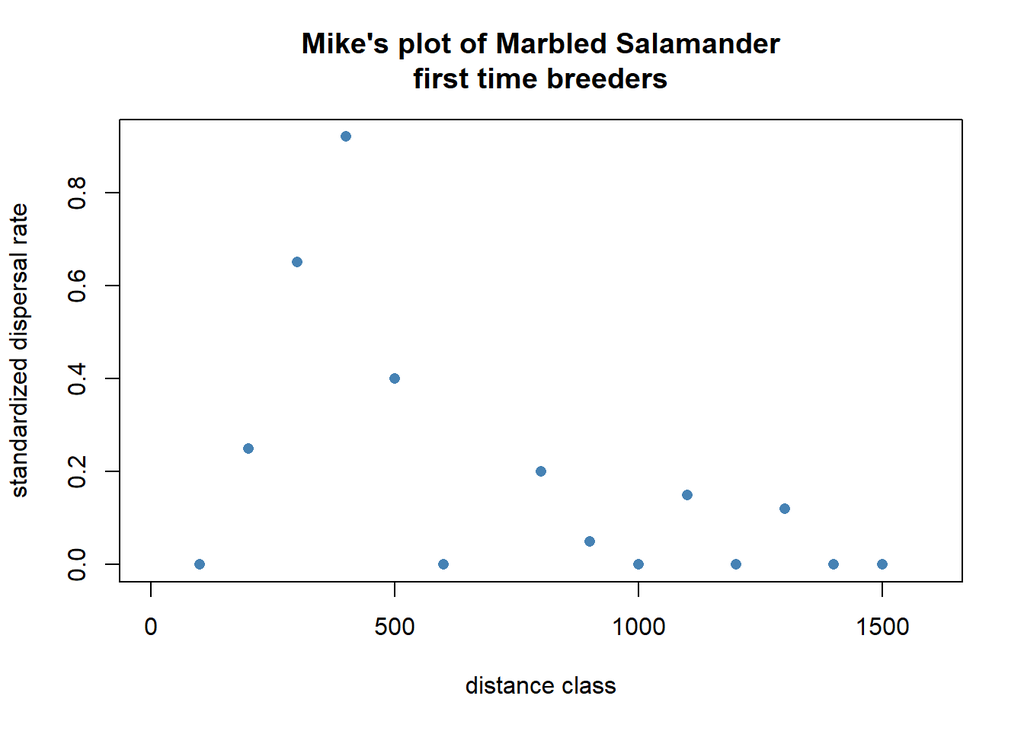

We’ll use the `predict()` function with our fitted `nls` model. The `predict()` function requires a data.frame that contains values of the predictor variables. It is a little bit picky though, the columns of the data frame have to have exactly the same names as the predictor variables used to build the model.

The first step is to make such a data frame:

```r
dist_newdata = data.frame(dist.class = seq(0, 1600, length.out = 1600))
```

Now we can plot the results of our model!

The `lines()` function will add to an existing plot:

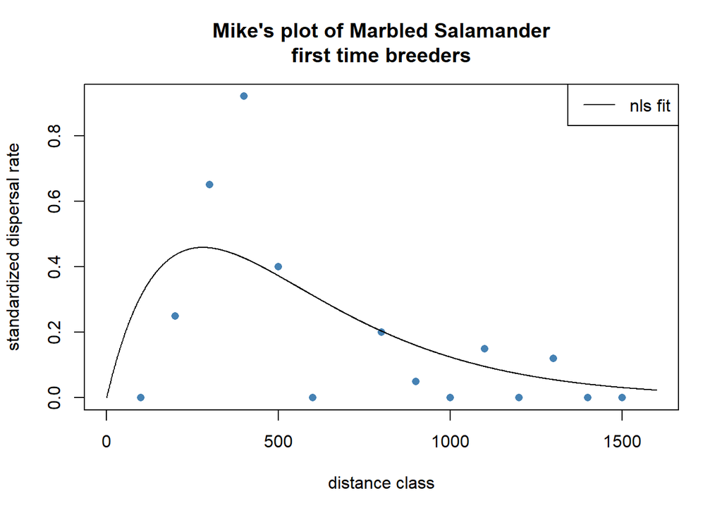

```r
lines(predict(fit_ricker_nls, newdata = dist_newdata))
legend("topright", legend = c("nls fit"), lty = 1, col = c(1))
```

## Adding your ‘guess’ model

Now let’s plot the model you fit visually. Refer back to lab 5 if you need a refresher.

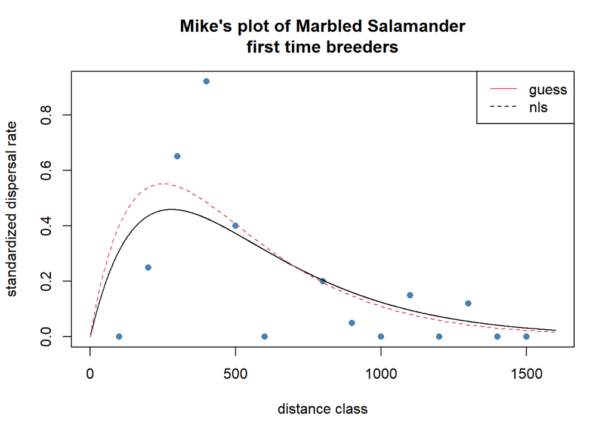

# Logistic Regression

Let’s revisit those logistic models of bird presence/absence that we fit *by hand* way back in lab 3!

## Cedar Waxwing Presence/Absence

Review the lab 3 document if you need a refresher on the data set.

Here’s a quick reminder of how the cedar waxwing presence/absence data look when plotted against elevation, slope, and total basal area.

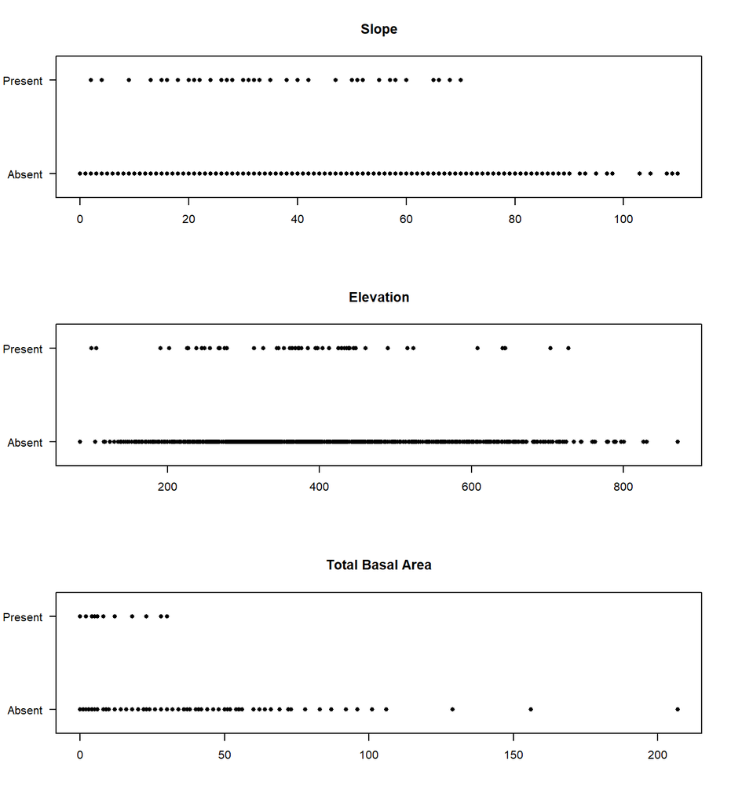

## Binary outcome data

We know that our Group 1 models don’t work for binary response variables. We’ve discussed a few alternatives in class, including Generalized Linear Models (GLMs).

We’ll fit logistic models, which are a type of GLM that work with binary outcomes.

The syntax is very similar to what we used when fitting Group 1 models using `lm()`

Here’s how I could fit a series of models using total basal area and slope:

```r
# Cedar waxwing presence/absence
dat_all$CEWA_TF = dat_all$CEWA > 0

# Create model fits
fit_slope = glm(CEWA_TF ~ slope, data = dat_all, family = binomial)
fit_ba_tot = glm(CEWA_TF ~ ba.tot, data = dat_all, family = binomial)
fit_both_additive = glm(CEWA_TF ~ slope + ba.tot, data = dat_all, family = binomial)
fit_both_interactive = glm(CEWA_TF ~ slope * ba.tot, data = dat_all, family = binomial)
```

Notice the similarity to the `lm()` syntax.

Notice also the addition of the `family = binomial` argument. This tells `glm()` that you want to do a logistic regression.

Let’s look at the summary for the additive model:

```r
summary(fit_both_additive)
```

```
##
## Call:
## glm(formula = CEWA_TF ~ slope + ba.tot, family = binomial, data = dat_all)
##
## Deviance Residuals:
##     Min       1Q   Median       3Q      Max
## -0.9365  -0.3608  -0.1543  -0.0600   3.1646
##
## Coefficients:
##              Estimate Std. Error z value Pr(>|z|)
## (Intercept) -0.552921   0.346427  -1.596  0.11047
## slope       -0.022062   0.006976  -3.162  0.00156 **
## ba.tot      -0.127335   0.021405  -5.949  2.7e-09 ***
## ---
## Signif. codes:  0 '***' 0.001 '**' 0.01 '*' 0.05 '.' 0.1 ' ' 1
##
## (Dispersion parameter for binomial family taken to be 1)
##
##     Null deviance: 419.41  on 1045  degrees of freedom
## Residual deviance: 331.93  on 1043  degrees of freedom
## AIC: 337.93
##
## Number of Fisher Scoring iterations: 8
```

- Does either predictor have a significant slope coefficient?
- Notice how the values of the elevation and slope differ over an order of magnitude.
- Can you think of any interpretation difficulties this might cause?

## Plotting a fitted model

Here’s a plot of the single-factor models:

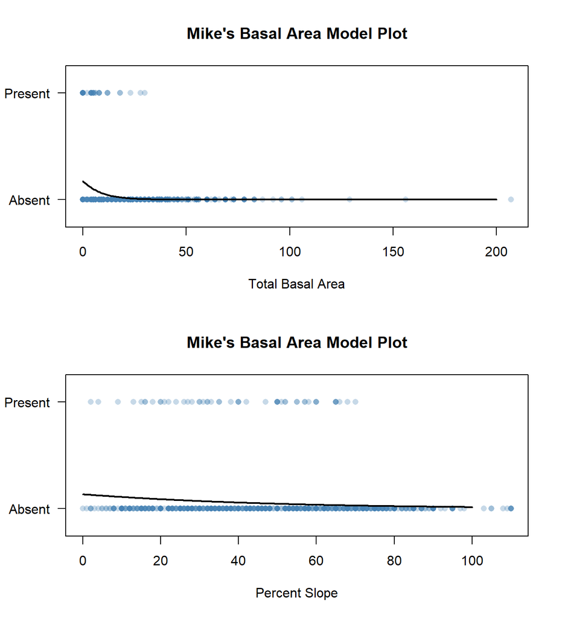

- Do the shapes of the fitted model surprise you?
- See if you can make the models make intuitive sense:
  - Consider how many sites at which the bird was present vs. absent.
  - Look at the horizontal distribution of presence and absense points.

# Lab Questions

## Q1: LOWESS

**Instructions**:

1. Review the population dispersion and statistical power simulation you created for Lab 11.
2. Re-run the simulation with with a small number of replicates, say 30, so that you get a jagged plot.
3. Fit a LOWESS model using 30% of the data.
4. Create a plot like the one I showed above of your simulated data and your fitted LOWESS model. Your plot must show:
   - The smooth LOWESS line
   - Points representing the simulation data.
   - An appropriate legend, title, and axis labels
- **Q1 (2 pts.):** Include your plot in your lab report.

## Q2: NLS

**Instructions**

1. Follow the lab walkthrough and make sure you can recreate the plots.
2. Review the *exponential* model you fit in lab 5.
3. Fit an NLS *exponential* model to the marbled salamander data.
4. Create a plot of your NLS and visually-fitted exponential models. Your plot must include:
   - A line for your visually-estimated model.
   - A line for your model fit via NLS.
   - Appropriate legend, title, and axis labels.
- **Q2 (2 pts.):** Include your plot in your lab report.

## Q3-5: Logistic Model

**Instructions**

1. Z-standardize the the slope and total basal area columns of the bird data.
   - Review Lab 9 if you need a refresher.
2. Fit four logistic models of cedar waxwing presence/absence as predicted by:
   - standardized slope
   - standardized total basal area
   - standardized slope and basal area (additive)
   - standardized slope and basal area (interactive)

**Q3 (0.5 pts.):** What are the AIC values for each of the 4 models?

**Q4 (0.5 pts.):** Which model would you choose, and why?

**Q5 (1 pt.):** Based on the model coefficient table of your chosen model, describe the direction and significance of the relationship(s) of the predictor variable or variables to the binary response. Make sure your answer is in terms of the ecological context.

# Report

Include the answers to the questions you decided to work on in a report and upload it to Moodle. An html document rendered from an RMarkdown is preferred, but I’ll also accept files in pdf or docx format.